# Association Between Race and COVID-19 Death Rates

### Causal Diagram

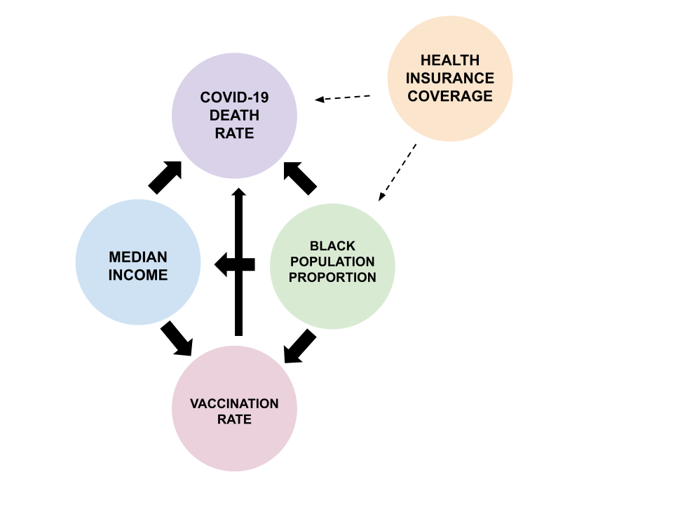

### How the Data was Merged

```r
ACS <- read.csv("acs2018_county_small.csv") #read ACS data
nyt_covid <- read.csv("us-counties-2021.csv") #read NYT data
county_vaccination <- read.csv("COVID-19_Vaccinations_in_the_United_States_County.csv") #read CDC data
county_vax_clean <- county_vaccination %>%
   filter(Date == "12/31/2021") %>% #take the values for last day of 2021 (data is cumulative)
   select(FIPS, Series_Complete_Pop_Pct)
county_vax_clean <- county_vax_clean %>%
   dplyr::rename(vax_rate = Series_Complete_Pop_Pct) %>% #rename variables for merging
   dplyr::rename(fips = FIPS)
clean_covid <- nyt_covid %>%
   group_by(fips) %>%
   filter(date == "2021-12-31") %>% #take the values for last day of 2021 (data is cumulative)
   dplyr::rename(total_cases = cases) %>% #rename variables for merging
   dplyr::rename(total_deaths = deaths) %>%
   select(fips, total_cases, total_deaths)
ACS_Covid <- merge(ACS, clean_covid, by = "fips", all = TRUE) #merge
ACS_Covid_Vax <- merge(ACS_Covid, county_vax_clean, by = "fips") %>%
   mutate(death_rate = (total_deaths/pop_total)*1000) %>% #calculate death rate per 100,000
   select(fips, death_rate, vax_rate, median_income, white_pct, black_pct)
 write.csv(ACS_Covid_Vax, file = "ACS_Covid_Vax.csv") #write a new file for the final dataset
```

The final merged dataset has 2,812 observations. The unit of observation is county and there are 5 variables: ‘death_rate’, ‘vax_rate’, ‘median_income’, ‘white_pct’, and ‘black_pct’.

## Bibliography

Chin-Hong, Peter, Kevin M. Alexander, Norrisa Haynes, Michelle A. Albert, and The Association of Black Cardiologists. “Pulling at the Heart: COVID-19, Race/Ethnicity and Ongoing Disparities.” Nature Reviews Cardiology 17 (September 2020): 533-35.

Eligon, John, Audra D.S Burch, Dionne Searcey, and Richard A. Oppel, Jr. “Black Americans Face Alarming Rates of Coronavirus Infection in Some States.” The New York Times (New York, NY), April 14, 2020. https://www.nytimes.com/2020/04/07/us/coronavirus-race.html.

Golestaneh, Ladan, Joel Neugarten, Molly Fisher, Henny H. Billett, Morayma Reyes Gil, Tanya Johns, Milagros Yunes, Michele H. Mokrzycki, Maria Coco, Keith C. Norris, Hector R. Perez, ShaniScott, Ryung S. Kim, and Eran Bellin. “The Association of Race and COVID-19 Mortality.”EClinicalMedicine 25 (August 2020): 1-7. https://doi.org/10.1016/j.eclinm.2020.100455.

Nguyen, Christina A., Michael E. Chernow, Isabel Ostrer, and Nancy D. Beaulieu. “Comparison ofHealthcare Delivery Systems in Low- and High-Income Communities.” The American Journal of Accountable Care 7, no. 4 (December 2019): 11-18. https://www.ajmc.com/view/comparison-of-healthcare-delivery-systems-in-low-and-highincome-communities.